# 6월 10일 ggplot2 과제

황 성 윤

2019 6 10

# ggplot2 패키지 및 R Markdown 활용

## 다음의 문제를 R Markdown 보고서(HTML 형식)로 제출하시오.

##### ggplot2 패키지 설치 및 열기

```r
library(ggplot2)
```

### 1. mpg 데이터의 cty(도시 연비)와 hwy(고속도로 연비) 간에 어떤 관계가 있는지 알아보려고 합니다. x축은 cty, y축은 hwy로 된 산점도를 만들어 보세요.

##### mpg 데이터 확인

```r
mpg
```

```
## # A tibble: 234 x 11
##    manufacturer model displ  year   cyl trans drv     cty   hwy fl    class
##    <chr>        <chr> <dbl> <int> <int> <chr> <chr> <int> <int> <chr> <chr>
##  1 audi         a4      1.8  1999     4 auto~ f        18    29 p     comp~
##  2 audi         a4      1.8  1999     4 manu~ f        21    29 p     comp~
##  3 audi         a4      2    2008     4 manu~ f        20    31 p     comp~
##  4 audi         a4      2    2008     4 auto~ f        21    30 p     comp~
##  5 audi         a4      2.8  1999     6 auto~ f        16    26 p     comp~
##  6 audi         a4      2.8  1999     6 manu~ f        18    26 p     comp~
##  7 audi         a4      3.1  2008     6 auto~ f        18    27 p     comp~
##  8 audi         a4 q~   1.8  1999     4 manu~ 4        18    26 p     comp~
##  9 audi         a4 q~   1.8  1999     4 auto~ 4        16    25 p     comp~
## 10 audi         a4 q~   2    2008     4 manu~ 4        20    28 p     comp~
## # ... with 224 more rows
```

```r
str(mpg)
```

```
## Classes 'tbl_df', 'tbl' and 'data.frame':    234 obs. of  11 variables:
##  $ manufacturer: chr  "audi" "audi" "audi" "audi" ...
##  $ model       : chr  "a4" "a4" "a4" "a4" ...
##  $ displ       : num  1.8 1.8 2 2 2.8 2.8 3.1 1.8 1.8 2 ...
##  $ year        : int  1999 1999 2008 2008 1999 1999 2008 1999 1999 2008 ...
##  $ cyl         : int  4 4 4 4 6 6 6 4 4 4 ...
##  $ trans       : chr  "auto(l5)" "manual(m5)" "manual(m6)" "auto(av)" ...
##  $ drv         : chr  "f" "f" "f" "f" ...
##  $ cty         : int  18 21 20 21 16 18 18 18 16 20 ...
##  $ hwy         : int  29 29 31 30 26 26 27 26 25 28 ...
##  $ fl          : chr  "p" "p" "p" "p" ...
##  $ class       : chr  "compact" "compact" "compact" "compact" ...
```

##### Drawing scatter plot

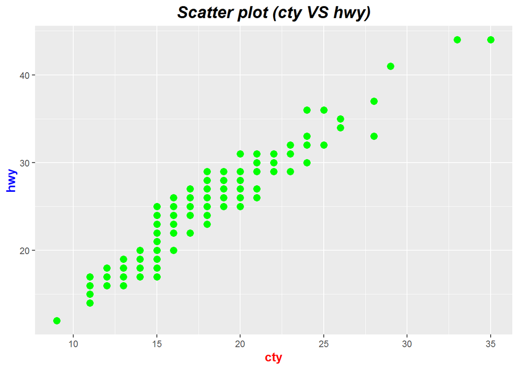

```r
ggplot(mpg,aes(x=cty,y=hwy)) + geom_point(color='green',size=3) +
  ggtitle("Scatter plot (cty VS hwy)") +
  theme(plot.title = element_text(color="black",size=16,face="bold.italic",hjust=0.5),
    axis.title.x = element_text(color="red",size=12,face="bold"),
    axis.title.y = element_text(color="blue",size=12,face="bold"))
```

### 2. 미국 지역별 인구통계 정보를 담은 ggplot2 패키지의 midwest 데이터를 이용해서 전체 인구와 아시아인 인구 간에 어떤 관계가 있는지 알아보려고 합니다. x축은 poptotal(전체 인구), y축은 popasian(아시아인 인구)으로 된 산점도를 만들어 보세요. 전체 인구는 50만 명 이하, 아시아인 인구는 1만 명 이하인 지역만 산점도에 표시되게 설정하세요.

##### midwest 데이터 확인

```r
midwest
```

```
## # A tibble: 437 x 28
##      PID county state  area poptotal popdensity popwhite popblack
##    <int> <chr>  <chr> <dbl>    <int>      <dbl>    <int>    <int>
##  1   561 ADAMS  IL    0.052    66090      1271.    63917     1702
##  2   562 ALEXA~ IL    0.014    10626       759      7054     3496
##  3   563 BOND   IL    0.022    14991       681.    14477      429
##  4   564 BOONE  IL    0.017    30806      1812.    29344      127
##  5   565 BROWN  IL    0.018     5836       324.     5264      547
##  6   566 BUREAU IL    0.05     35688       714.    35157       50
##  7   567 CALHO~ IL    0.017     5322       313.     5298        1
##  8   568 CARRO~ IL    0.027    16805       622.    16519      111
##  9   569 CASS   IL    0.024    13437       560.    13384       16
## 10   570 CHAMP~ IL    0.058   173025      2983.   146506    16559
## # ... with 427 more rows, and 20 more variables: popamerindian <int>,
## #   popasian <int>, popother <int>, percwhite <dbl>, percblack <dbl>,
## #   percamerindan <dbl>, percasian <dbl>, percother <dbl>,
## #   popadults <int>, perchsd <dbl>, percollege <dbl>, percprof <dbl>,
## #   poppovertyknown <int>, percpovertyknown <dbl>, percbelowpoverty <dbl>,
## #   percchildbelowpovert <dbl>, percadultpoverty <dbl>,
## #   percelderlypoverty <dbl>, inmetro <int>, category <chr>
```

```r
str(midwest)
```

```
## Classes 'tbl_df', 'tbl' and 'data.frame':    437 obs. of  28 variables:
##  $ PID                 : int  561 562 563 564 565 566 567 568 569 570 ...
##  $ county              : chr  "ADAMS" "ALEXANDER" "BOND" "BOONE" ...
##  $ state               : chr  "IL" "IL" "IL" "IL" ...
##  $ area                : num  0.052 0.014 0.022 0.017 0.018 0.05 0.017 0.027 0.024 0.058 ...
##  $ poptotal            : int  66090 10626 14991 30806 5836 35688 5322 16805 13437 173025 ...
##  $ popdensity          : num  1271 759 681 1812 324 ...
##  $ popwhite            : int  63917 7054 14477 29344 5264 35157 5298 16519 13384 146506 ...
##  $ popblack            : int  1702 3496 429 127 547 50 1 111 16 16559 ...
##  $ popamerindian       : int  98 19 35 46 14 65 8 30 8 331 ...
##  $ popasian            : int  249 48 16 150 5 195 15 61 23 8033 ...
##  $ popother            : int  124 9 34 1139 6 221 0 84 6 1596 ...
##  $ percwhite           : num  96.7 66.4 96.6 95.3 90.2 ...
##  $ percblack           : num  2.575 32.9 2.862 0.412 9.373 ...
##  $ percamerindan       : num  0.148 0.179 0.233 0.149 0.24 ...
##  $ percasian           : num  0.3768 0.4517 0.1067 0.4869 0.0857 ...
##  $ percother           : num  0.1876 0.0847 0.2268 3.6973 0.1028 ...
##  $ popadults           : int  43298 6724 9669 19272 3979 23444 3583 11323 8825 95971 ...
##  $ perchsd             : num  75.1 59.7 69.3 75.5 68.9 ...
##  $ percollege          : num  19.6 11.2 17 17.3 14.5 ...
##  $ percprof            : num  4.36 2.87 4.49 4.2 3.37 ...
##  $ poppovertyknown     : int  63628 10529 14235 30337 4815 35107 5241 16455 13081 154934 ...
##  $ percpovertyknown    : num  96.3 99.1 95 98.5 82.5 ...
##  $ percbelowpoverty    : num  13.15 32.24 12.07 7.21 13.52 ...
##  $ percchildbelowpovert: num  18 45.8 14 11.2 13 ...
##  $ percadultpoverty    : num  11.01 27.39 10.85 5.54 11.14 ...
##  $ percelderlypoverty  : num  12.44 25.23 12.7 6.22 19.2 ...
##  $ inmetro             : int  0 0 0 1 0 0 0 0 0 1 ...
##  $ category            : chr  "AAR" "LHR" "AAR" "ALU" ...
```

##### Drawing scatter plot

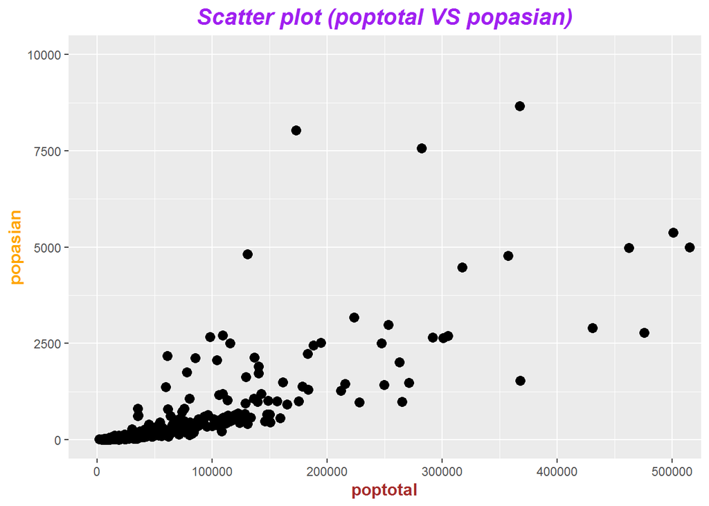

```r
options(scipen=100)
ggplot(midwest,aes(x=poptotal,y=popasian)) +
  geom_point(color='black',size=3) +
  coord_cartesian(xlim = c(0,500000), ylim = c(0,10000)) +
  ggtitle("Scatter plot (poptotal VS popasian)") +
  theme(plot.title = element_text(color="purple",size=16,face="bold.italic",hjust=0.5),
    axis.title.x = element_text(color="brown",size=12,face="bold"),
    axis.title.y = element_text(color="orange",size=12,face="bold"))
```

### 3. 어떤 회사에서 생산한 “suv” 차종의 도시 연비가 높은지 알아보려고 합니다. “suv” 차종을 대상으로 평균 cty(도시 연비)가 가장 높은 회사 다섯 곳을 막대 그래프로 표현해 보세요. 막대는 연비가 높은 순으로 정렬하세요.

##### suv 차종 대상 상위 5곳의 평균 cty 확인

```r
library(dplyr)
mpg %>%
  filter(class=="suv") %>%
  group_by(manufacturer) %>%
  summarise(average=mean(cty,na.rm=T)) %>%
  arrange(desc(average)) %>%
  head(5)
```

```
## # A tibble: 5 x 2
##   manufacturer average
##   <chr>          <dbl>
## 1 subaru          18.8
## 2 toyota          14.4
## 3 nissan          13.8
## 4 jeep            13.5
## 5 mercury         13.2
```

확인 결과, suv 차종 대상으로 subaru, toyota, nissan, jeep, mercury 의 차량이 평균 도시 연비가 높은 것으로 나타남.

##### Drawing barplot

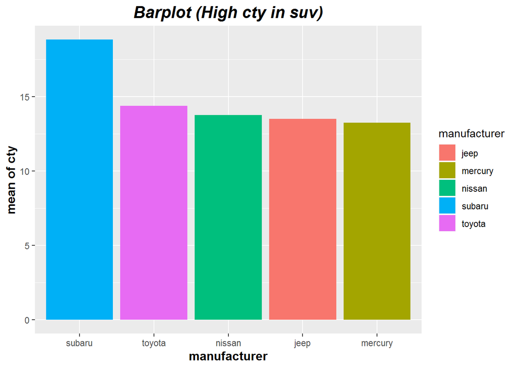

```r
select_mpg <- mpg %>%
  group_by(manufacturer) %>%
  filter(class=="suv") %>%
  filter(manufacturer %in% c('subaru','toyota','nissan','jeep','mercury')) %>%
  summarise(average=mean(cty,na.rm=T)) %>%
  arrange(desc(average))
ggplot(select_mpg,aes(x=reorder(manufacturer,-average),y=average,fill=manufacturer)) +
  geom_bar(stat="identity") +
  xlab("manufacturer") + ylab("mean of cty") +
  ggtitle("Barplot (High cty in suv)") +
  theme(plot.title = element_text(color="black",size=16,face="bold.italic",hjust=0.5),
        axis.title.x = element_text(color="black",size=12,face="bold"),
        axis.title.y = element_text(color="black",size=12,face="bold"))
```

### 4. 자동차 중에서 어떤 class(자동차 종류)가 가장 많은지 알아보려고 합니다. 자동차 종류별 빈도를 표현한 막대 그래프를 만들어 보세요.

##### 자동차 종류에 따른 빈도수 확인

```r
number_mpg <- mpg %>%
  group_by(class) %>%
  summarise(number=length(class))
```

##### Drawing barplot

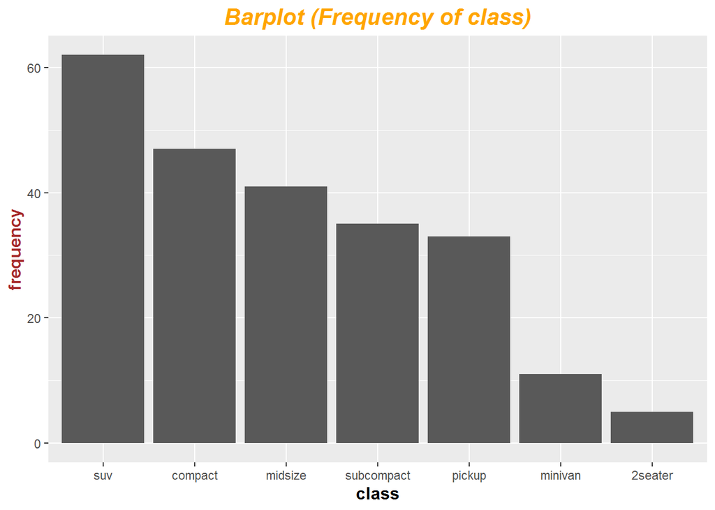

```r
ggplot(number_mpg,aes(x=reorder(class,-number),y=number)) +
  geom_bar(stat="identity") +
  xlab("class") + ylab("frequency") +
  ggtitle("Barplot (Frequency of class)") +
  theme(plot.title = element_text(color="orange",size=16,face="bold.italic",hjust=0.5),
        axis.title.x = element_text(color="black",size=12,face="bold"),
        axis.title.y = element_text(color="brown",size=12,face="bold"))
```

### 5. economics 데이터를 이용해서 psavert(개인 저축률)가 시간에 따라서 어떻게 변해왔는지 알아보려고 합니다. 시간에 따른 개인 저축률의 변화를 나타낸 시계열 그래프를 만들어 보세요.

##### economics 데이터 확인

```r
economics
```

```
## # A tibble: 574 x 6
##    date         pce    pop psavert uempmed unemploy
##    <date>     <dbl>  <int>   <dbl>   <dbl>    <int>
##  1 1967-07-01  507. 198712    12.5     4.5     2944
##  2 1967-08-01  510. 198911    12.5     4.7     2945
##  3 1967-09-01  516. 199113    11.7     4.6     2958
##  4 1967-10-01  513. 199311    12.5     4.9     3143
##  5 1967-11-01  518. 199498    12.5     4.7     3066
##  6 1967-12-01  526. 199657    12.1     4.8     3018
##  7 1968-01-01  532. 199808    11.7     5.1     2878
##  8 1968-02-01  534. 199920    12.2     4.5     3001
##  9 1968-03-01  545. 200056    11.6     4.1     2877
## 10 1968-04-01  545. 200208    12.2     4.6     2709
## # ... with 564 more rows
```

```r
str(economics)
```

```
## Classes 'tbl_df', 'tbl' and 'data.frame':    574 obs. of  6 variables:
##  $ date    : Date, format: "1967-07-01" "1967-08-01" ...
##  $ pce     : num  507 510 516 513 518 ...
##  $ pop     : int  198712 198911 199113 199311 199498 199657 199808 199920 200056 200208 ...
##  $ psavert : num  12.5 12.5 11.7 12.5 12.5 12.1 11.7 12.2 11.6 12.2 ...
##  $ uempmed : num  4.5 4.7 4.6 4.9 4.7 4.8 5.1 4.5 4.1 4.6 ...
##  $ unemploy: int  2944 2945 2958 3143 3066 3018 2878 3001 2877 2709 ...
```

##### Drawing time series plot

월별에 따른 개인 저축률의 변화를 보여주는 시계열 그래프

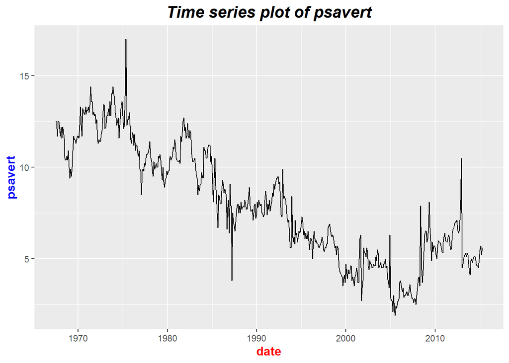

```r
ggplot(economics,aes(x=date,y=psavert)) +
  geom_line() +
  ggtitle("Time series plot of psavert") +
  theme(plot.title = element_text(color="black",size=16,face="bold.italic",hjust=0.5),
        axis.title.x = element_text(color="red",size=12,face="bold"),
        axis.title.y = element_text(color="blue",size=12,face="bold"))
```

### 6. class(자동차 종류)가 “compact”, “subcompact”, “suv”인 자동차의 cty(도시 연비)가 어떻게 다른지 비교해보려고 합니다. 세 차종의 cty를 나타낸 상자 그림을 만들어보세요.

##### 해당 차종과 관련있는 데이터 추출

```r
find_mpg <- mpg %>%
  filter(class %in% c("compact","subcompact","suv")) %>%
  group_by(class)
find_mpg
```

```
## # A tibble: 144 x 11
## # Groups:   class [3]
##    manufacturer model displ  year   cyl trans drv     cty   hwy fl    class
##    <chr>        <chr> <dbl> <int> <int> <chr> <chr> <int> <int> <chr> <chr>
##  1 audi         a4      1.8  1999     4 auto~ f        18    29 p     comp~
##  2 audi         a4      1.8  1999     4 manu~ f        21    29 p     comp~
##  3 audi         a4      2    2008     4 manu~ f        20    31 p     comp~
##  4 audi         a4      2    2008     4 auto~ f        21    30 p     comp~
##  5 audi         a4      2.8  1999     6 auto~ f        16    26 p     comp~
##  6 audi         a4      2.8  1999     6 manu~ f        18    26 p     comp~
##  7 audi         a4      3.1  2008     6 auto~ f        18    27 p     comp~
##  8 audi         a4 q~   1.8  1999     4 manu~ 4        18    26 p     comp~
##  9 audi         a4 q~   1.8  1999     4 auto~ 4        16    25 p     comp~
## 10 audi         a4 q~   2    2008     4 manu~ 4        20    28 p     comp~
## # ... with 134 more rows
```

##### Drawing boxplot

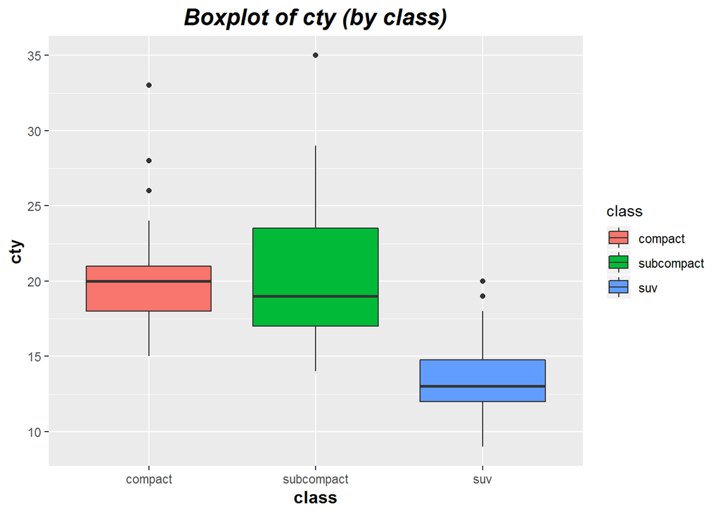

```r
ggplot(find_mpg,aes(x=class,y=cty,fill=class)) +
  geom_boxplot() +
  ggtitle("Boxplot of cty (by class)") +
  theme(plot.title = element_text(color="black",size=16,face="bold.italic",hjust=0.5),
        axis.title.x = element_text(color="black",size=12,face="bold"),
        axis.title.y = element_text(color="black",size=12,face="bold"))
```

### 7. Diamonds 데이터 셋을 이용하여 다음 문제를 해결하세요. 단, 컬러, 제목, x축, y축 등 그래프를 예쁘게 작성하세요.

##### Diamonds 데이터 확인

```r
diamonds
```

```
## # A tibble: 53,940 x 10
##    carat cut       color clarity depth table price     x     y     z
##    <dbl> <ord>     <ord> <ord>   <dbl> <dbl> <int> <dbl> <dbl> <dbl>
##  1 0.23  Ideal     E     SI2      61.5    55   326  3.95  3.98  2.43
##  2 0.21  Premium   E     SI1      59.8    61   326  3.89  3.84  2.31
##  3 0.23  Good      E     VS1      56.9    65   327  4.05  4.07  2.31
##  4 0.290 Premium   I     VS2      62.4    58   334  4.2   4.23  2.63
##  5 0.31  Good      J     SI2      63.3    58   335  4.34  4.35  2.75
##  6 0.24  Very Good J     VVS2     62.8    57   336  3.94  3.96  2.48
##  7 0.24  Very Good I     VVS1     62.3    57   336  3.95  3.98  2.47
##  8 0.26  Very Good H     SI1      61.9    55   337  4.07  4.11  2.53
##  9 0.22  Fair      E     VS2      65.1    61   337  3.87  3.78  2.49
## 10 0.23  Very Good H     VS1      59.4    61   338  4     4.05  2.39
## # ... with 53,930 more rows
```

```r
str(diamonds)
```

```
## Classes 'tbl_df', 'tbl' and 'data.frame':    53940 obs. of  10 variables:
##  $ carat  : num  0.23 0.21 0.23 0.29 0.31 0.24 0.24 0.26 0.22 0.23 ...
##  $ cut    : Ord.factor w/ 5 levels "Fair"<"Good"<..: 5 4 2 4 2 3 3 3 1 3 ...
##  $ color  : Ord.factor w/ 7 levels "D"<"E"<"F"<"G"<..: 2 2 2 6 7 7 6 5 2 5 ...
##  $ clarity: Ord.factor w/ 8 levels "I1"<"SI2"<"SI1"<..: 2 3 5 4 2 6 7 3 4 5 ...
##  $ depth  : num  61.5 59.8 56.9 62.4 63.3 62.8 62.3 61.9 65.1 59.4 ...
##  $ table  : num  55 61 65 58 58 57 57 55 61 61 ...
##  $ price  : int  326 326 327 334 335 336 336 337 337 338 ...
##  $ x      : num  3.95 3.89 4.05 4.2 4.34 3.94 3.95 4.07 3.87 4 ...
##  $ y      : num  3.98 3.84 4.07 4.23 4.35 3.96 3.98 4.11 3.78 4.05 ...
##  $ z      : num  2.43 2.31 2.31 2.63 2.75 2.48 2.47 2.53 2.49 2.39 ...
```

#### 1) cut의 도수를 보여주는 그래프를 작성하세요.

##### cut에 따른 도수 확인

```r
number_diamonds <- diamonds %>%
  group_by(cut) %>%
  summarise(number=length(cut))
number_diamonds
```

```
## # A tibble: 5 x 2
##   cut       number
##   <ord>      <int>
## 1 Fair        1610
## 2 Good        4906
## 3 Very Good  12082
## 4 Premium    13791
## 5 Ideal      21551
```

##### Drawing barplot

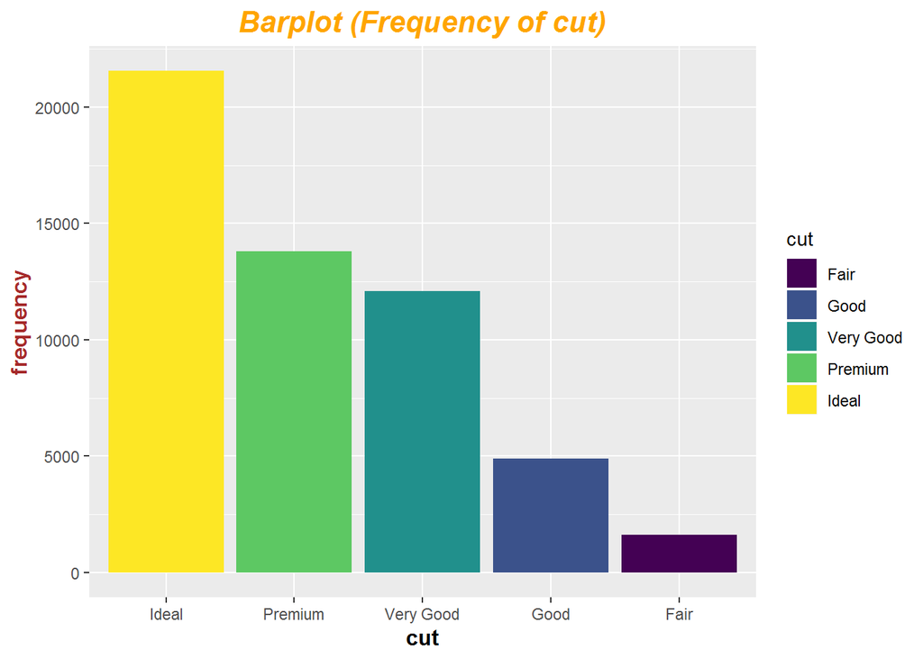

```r
ggplot(number_diamonds,aes(x=reorder(cut,-number),y=number,fill=cut)) +
  geom_bar(stat="identity") +
  xlab("cut") + ylab("frequency") +
  ggtitle("Barplot (Frequency of cut)") +
  theme(plot.title = element_text(color="orange",size=16,face="bold.italic",hjust=0.5),
        axis.title.x = element_text(color="black",size=12,face="bold"),
        axis.title.y = element_text(color="brown",size=12,face="bold"))
```

#### 2) cut에 따른 가격의 변화를 보여주는 그래프를 작성하세요.

##### cut에 따른 가격의 평균값 확인

```r
sort_diamonds <- diamonds %>%
  group_by(cut) %>%
  summarise(average=mean(price,na.rm=T)) %>%
  arrange(desc(average))
sort_diamonds
```

```
## # A tibble: 5 x 2
##   cut       average
##   <ord>       <dbl>
## 1 Premium     4584.
## 2 Fair        4359.
## 3 Very Good   3982.
## 4 Good        3929.
## 5 Ideal       3458.
```

##### Drawing barplot

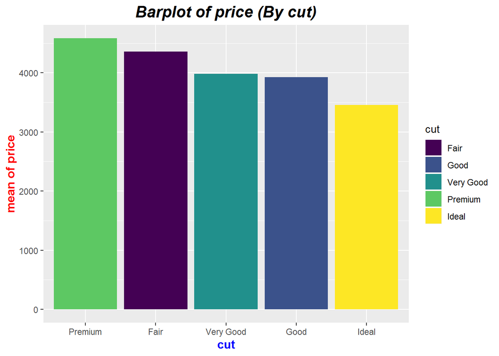

```r
ggplot(sort_diamonds,aes(x=reorder(cut,-average),y=average,fill=cut)) +
  geom_bar(stat="identity") +
  xlab("cut") + ylab("mean of price") +
  ggtitle("Barplot of price (By cut)") +
  theme(plot.title = element_text(color="black",size=16,face="bold.italic",hjust=0.5),
        axis.title.x = element_text(color="blue",size=12,face="bold"),
        axis.title.y = element_text(color="red",size=12,face="bold"))
```

#### 3) cut과 color에 따른 가격의 변화를 보여주는 그래프를 작성하세요.

##### cut과 color에 따른 가격의 평균값 확인

```r
reorder_diamonds <- diamonds %>%
  group_by(cut,color) %>%
  summarise(average=mean(price,na.rm=T))
reorder_diamonds
```

```
## # A tibble: 35 x 3
## # Groups:   cut [5]
##    cut   color average
##    <ord> <ord>   <dbl>
##  1 Fair  D       4291.
##  2 Fair  E       3682.
##  3 Fair  F       3827.
##  4 Fair  G       4239.
##  5 Fair  H       5136.
##  6 Fair  I       4685.
##  7 Fair  J       4976.
##  8 Good  D       3405.
##  9 Good  E       3424.
## 10 Good  F       3496.
## # ... with 25 more rows
```

##### Drawing line graph

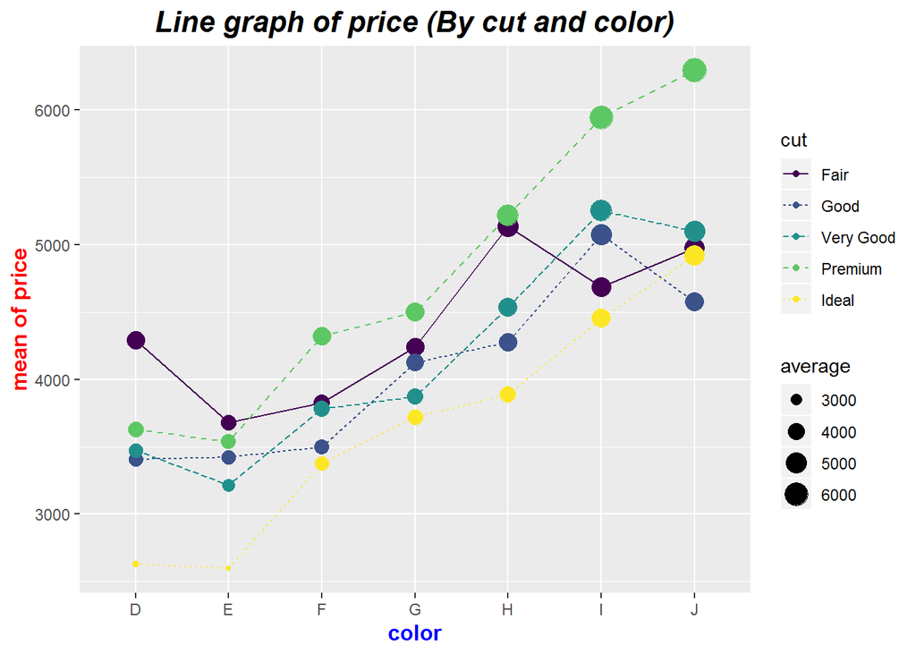

```r
ggplot(reorder_diamonds,aes(x=color,y=average,color=cut,group=cut,fill=cut)) +
  geom_line(aes(linetype=cut)) + geom_point(aes(size=average)) +
  xlab("color") + ylab("mean of price") +
  ggtitle("Line graph of price (By cut and color)") +
  theme(plot.title = element_text(color="black",size=16,face="bold.italic",hjust=0.5),
        axis.title.x = element_text(color="blue",size=12,face="bold"),
        axis.title.y = element_text(color="red",size=12,face="bold"))
```